# Global Health Spending

Author

Jo Hardin

Published

April 21, 2026

```r
library(tidyverse) # ggplot, lubridate, dplyr, stringr, readr...
library(praise)
```

# Global Health Spending

This week we’re exploring global health spending data. The [WHO Global Health Expenditure Database (GHED)](https://apps.who.int/nha/database) provides comparable data on health expenditure for 195 countries and territories since 2000.

The data tracks how much countries spend on health care, where the money comes from (government, private, or external sources), how it is channeled through financing schemes (e.g. government programmes, voluntary insurance, out-of-pocket payments), and what it is spent on (e.g. curative care, preventive care, medical goods). How health systems are funded and how resources are allocated directly shapes health outcomes, progress toward universal health coverage, and whether households face financial hardship when accessing care. These indicators are essential to inform health policy decisions.

The data is organised into three datasets:

- **`health_spending`** — Aggregate health spending and its breakdown by funding source (domestic government, domestic private, and external aid).
- **`financing_schemes`** — Health spending by financing scheme (e.g. government schemes, voluntary insurance, out-of-pocket payments).
- **`spending_purpose`** — Health spending by health care function (e.g. curative care, preventive care, medical goods).

```r
financing_schemes <- readr::read_csv('https://raw.githubusercontent.com/rfordatascience/tidytuesday/main/data/2026/2026-04-21/financing_schemes.csv')
health_spending <- readr::read_csv('https://raw.githubusercontent.com/rfordatascience/tidytuesday/main/data/2026/2026-04-21/health_spending.csv')
spending_purpose <- readr::read_csv('https://raw.githubusercontent.com/rfordatascience/tidytuesday/main/data/2026/2026-04-21/spending_purpose.csv')
```

## Visualization

```r
health_spending |>
  filter(indicator_code == "ext_che") |>
  arrange(desc(value))
```

```
# A tibble: 4,027 × 7
   country_name      iso3_code  year indicator_code expenditure_type value unit
   <chr>             <chr>     <dbl> <chr>          <chr>            <dbl> <chr>
 1 Micronesia (Fede… FSM        2005 ext_che        External Health…  81.6 % of…
 2 Micronesia (Fede… FSM        2021 ext_che        External Health…  79.9 % of…
 3 Micronesia (Fede… FSM        2010 ext_che        External Health…  79.0 % of…
 4 Micronesia (Fede… FSM        2009 ext_che        External Health…  78.5 % of…
 5 Gambia            GMB        2000 ext_che        External Health…  78.4 % of…
 6 Micronesia (Fede… FSM        2022 ext_che        External Health…  77.4 % of…
 7 Gambia            GMB        2001 ext_che        External Health…  76.7 % of…
 8 Micronesia (Fede… FSM        2004 ext_che        External Health…  76.0 % of…
 9 Micronesia (Fede… FSM        2012 ext_che        External Health…  75.9 % of…
10 Gambia            GMB        2002 ext_che        External Health…  75.4 % of…
# ℹ 4,017 more rows
```

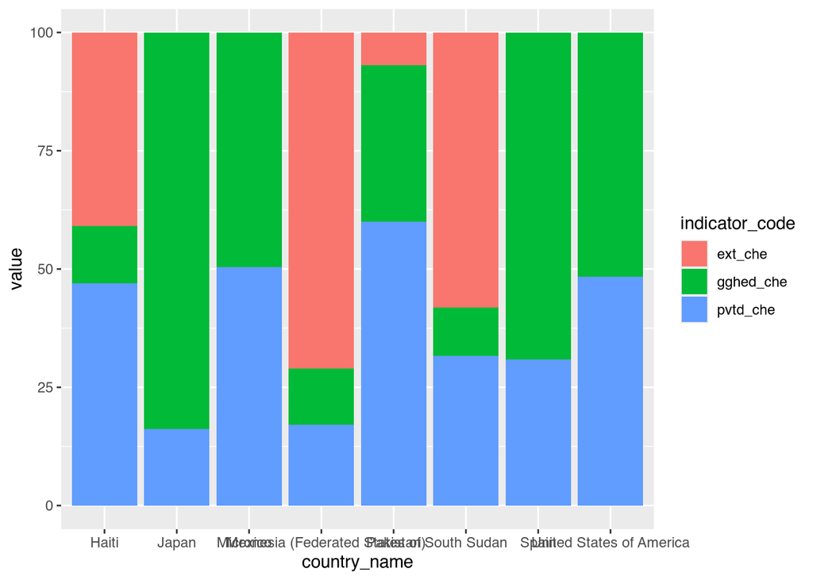

```r
health_spending |>
  filter(iso3_code %in% c("MEX", "ESP", "USA", "HTI", "SSD", "FSM", "PAK", "JPN")) |>
  filter(unit == "% of current health expenditure") |>
  filter(year == 2018) |>
  ggplot(aes(x = country_name, y = value, fill = indicator_code)) +
    geom_col(stat = "identity")
```

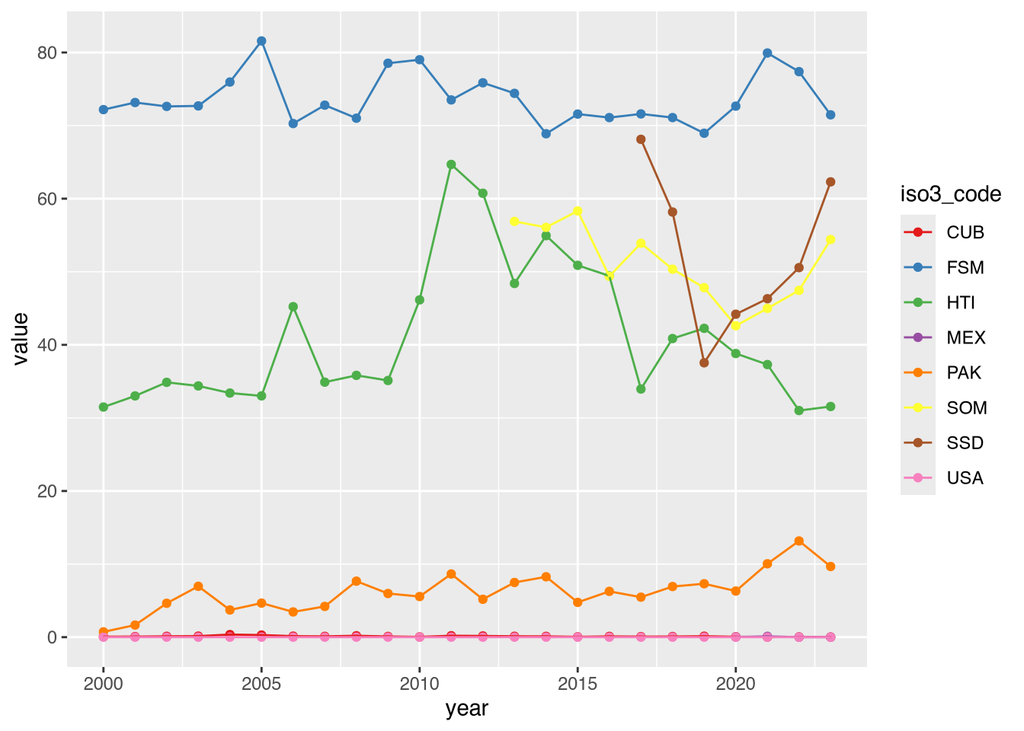

```r
health_spending |>
  filter(iso3_code %in% c("MEX", "ESP", "USA", "HTI", "SSD", "FSM", "PAK", "SOM", "CUB")) |>
  filter(indicator_code == "ext_che") |>
  ggplot(aes(x = year, y = value, color = iso3_code)) +
    geom_point() +
    geom_line() +
  scale_color_brewer(palette = "Set1")
```

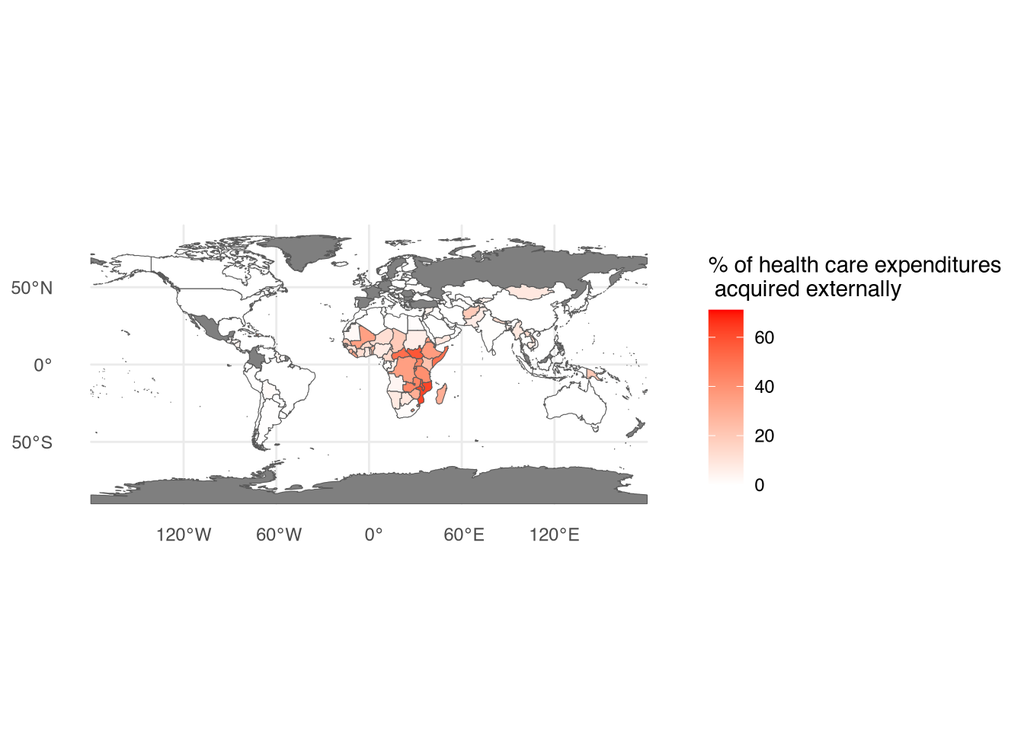

```r
library(rnaturalearth)

world <- ne_countries(scale = "medium", returnclass = "sf")


world_data <- world |>
  filter(iso_a3_eh != -99) |>
  left_join(health_spending |> filter(indicator_code == "ext_che"),
            by = c("iso_a3_eh" = "iso3_code"),
            relationship = "many-to-many") |>
  group_by(iso_a3_eh, geometry) |>
  complete(year = 2000:2023) |>
  ungroup() |>
  sf::st_as_sf()


world_data |>
  filter(year == 2018) |>
  ggplot() +
  geom_sf(aes(fill = value)) +
  scale_fill_gradient(low = "white", high = "red") +
  theme_minimal() +
  labs(title = "",
       fill = "% of health care expenditures\n acquired externally")
```

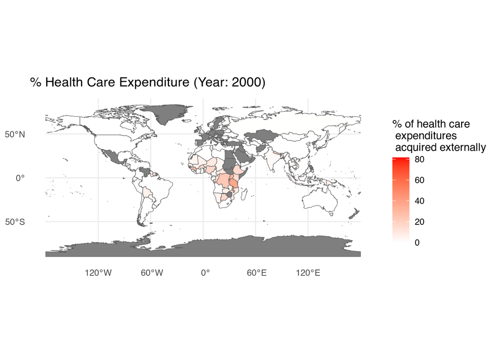

Map showing the proportion of total health care expenditure that is acquired externally. White indicates zero external health care expenditures. Grey indicates missing information about external health care expenditures.

```r
library(gganimate)
p <- world_data |>
  ggplot(aes(fill = value)) +
  geom_sf() +
  scale_fill_gradient(low = "white", high = "red") +
  theme_minimal() +
  labs(title = "% Health Care Expenditure (Year: {closest_state})",
       fill = "% of health care\n expenditures\n acquired externally") +
  transition_states(year, transition_length = 0, state_length = 1)

animate(p)
```

```r
praise()
```

```
[1] "You are fabulous!"
```